# Data analysis and visualization report on WeRateDogs tweet archive

## Introduction:

In this project, I intent to analyze the tweet archive of Twitter user [@dog_rates](https://twitter.com/dog_rates), also known as WeRateDogs. WeRateDogs is a Twitter account that rates people's dogs with a humorous comment about the dog. WeRateDogs asks people to send photos of their dogs, then tweets selected photos with a rating. Dogs are rated on a scale of one to ten, but are invariably given ratings in excess of the maximum, such as "13/10".

Every image in the tweet archive file is run through a neural network that can identify breeds of dogs and the top 3 predictions identified by the algorithm are included in the file for each tweet. The file is then cleaned and is used as an input for this analysis.

Note: Only the original tweets that has a rating for a dog are included in the input file and used for analysis.

## Analysis #1: How does the rating statistics look like?

Here is the descriptive statistics for the dog ratings:

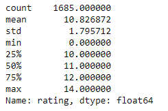

There are 1685 ratings with a mean rating of 10.8 and standard deviation of 1.8. The ratings range from 0 to 14. Even though the ratings are provided out of ten, the mean and the median ratings are above ten. This indicates that more dogs are rated above ten. Let's confirm this by looking at the actual numbers per rating.

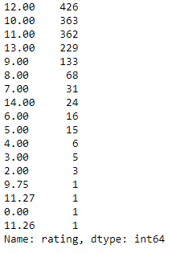

Out of 1685 dogs that were rated, 1043 dogs or 62% received a rating higher than 10. Let's look at the histogram of the rating distribution and see how the higher ratings skewed the distribution.

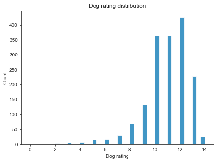

As seen from the above graph, the distribution of dog rating is left skewed.

## Insight #1:

The ratings range from 0 to 14 with a mean of 10.8 and standard deviation of 1.8. With a median rating of 11, which is slightly higher than the mean, the distribution of ratings is left skewed. The left skewness is also confirmed by the more number of dogs rated on the higher end of the scale (62% of the dogs received a rating of 11 or higher).

## Analysis #2: What it takes to be a top-rated dog?

From the previous analysis, we found out that the highest rating provided was 14/10 and there were 24 dogs that received this highest rating. What breeds of dogs got this honor? Let's find out.

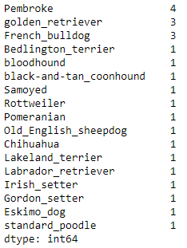

Pembroke is the winner. More than one dog from the Pembroke, Golden Retreiver and French Bulldog breeds received the highest rating. Few other breeds also received the honor as seen from the above table.

## Insight #2:

The top 24 dogs that were rated 14/10 belong to the following breeds:

| Breed | Count |
| --- | --- |
| Pembroke | 4 |
| Golden retriever | 3 |
| French bulldog | 3 |
| Bedlington terrier | 1 |
| Bloodhound | 1 |
| Black-and-tan coonhound | 1 |
| Samoyed | 1 |
| Rottweiler | 1 |
| Pomeranian | 1 |
| Old English sheepdog | 1 |
| Chihuahua | 1 |
| Lakeland terrier | 1 |
| Labrador retriever | 1 |
| Irish setter | 1 |
| Gordon setter | 1 |
| Eskimo dog | 1 |
| Standard poodle | 1 |

## Analysis #3: How does the rating influence tweets to be retweeted and/or favorited?

Since we want to look at the relationship between variables, let's do so with scatter plots.

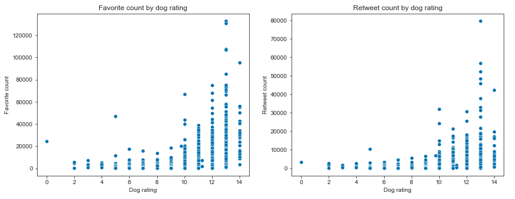

From the above graphs, it is clear that the favorite count and retweet count increase as the rating increases. Obviously, people like when the dogs receive higher ratings.

Out of curiosity, how does the relationship between Favorite count and Retweet count look like? Let's look at another scatter plot.

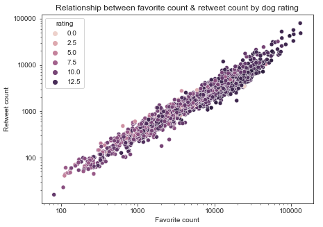

A strong positive correlation between the two. To be precise, the correlation coefficient between the two variables is 0.91.

## Insight #3:

In general, the favorite count and retweet count increase as the rating increases. Between favorite count and retweet count, there is a strong positive correlation with a correlation coefficient of 0.91.